# F1-Podium-ML-Project

# Outline of Analysis

## 1. Modeling Approach

This is a comparative analysis of four machine learning techniques aimed at identifying the most effective prediction method. Logistic regression was used as a standard baseline for binary classification tasks. LASSO logistic regression was utilized to introduce regularization and mitigate overfitting. The decision tree model was selected due to its interpretability and transparent splitting-rules, while random forest, an ensemble approach combining multiple decision trees, was included to enhance predictive accuracy.

## 2. Feature Selection Strategy

The feature selection strategy involved removing features with a correlation of 0.80 or higher, leading to the exclusion of `podium_rate`, `career_podiums`, `win_rate`, `races`, and `qual_pos`. Groups for feature importance were created using domain knowledge related to Formula 1. The final set of features consists of grid position, driver age, number of completed races, recent performance, and circuit characteristics.

Importance Matrix

|  | No_Podium | Podium | MeanDecreaseAccuracy | MeanDecreaseGini |
| --- | --- | --- | --- | --- |
| grid_pos | 134.396805 | 214.889070 | 233.601473 | 1218.13177 |
| driver_age | 28.509882 | 2.107339 | 28.871616 | 715.11987 |
| races_completed | 23.210771 | 29.623480 | 33.630111 | 683.11295 |
| last_race_position | 20.046256 | 16.758930 | 26.281903 | 538.41206 |
| circuitId | 11.242075 | -3.793837 | 7.871795 | 296.65180 |
| last_race_points | 15.747752 | 13.255501 | 22.034073 | 304.45641 |
| circuit_type | 4.344423 | 1.420543 | 4.821636 | 24.23993 |
| alt | 9.622654 | -2.131467 | 7.883744 | 290.62721 |
| lat | 8.529376 | 4.719195 | 9.961328 | 299.03739 |

Category Summary

| Category | Avg_Importance | Max_Importance | Count | Top_Feature |
| --- | --- | --- | --- | --- |
| Grid/Qualifying | 1218.1318 | 1218.1318 | 1 | grid_pos |
| Driver Experience | 699.1164 | 715.1199 | 2 | driver_age |
| Recent Performance | 421.4342 | 538.4121 | 2 | last_race_position |
| Other | 294.8323 | 299.0374 | 2 | lat |
| Circuit | 160.4459 | 296.6518 | 2 | circuitId |

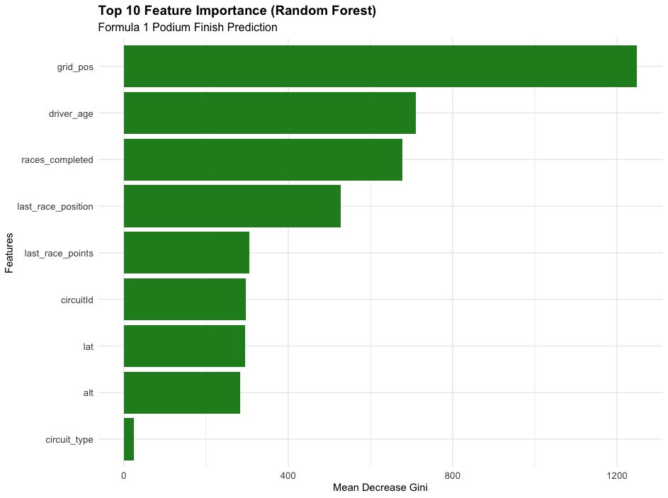

Feature Importance

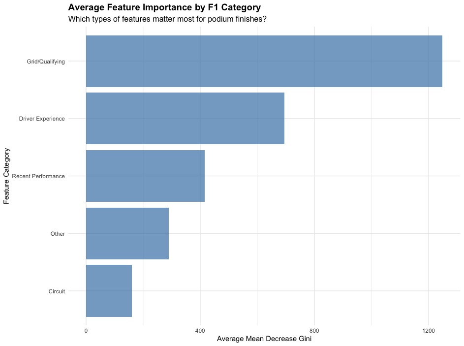

F1 Domain Knowledge Feature Importance

## 3. Evaluation Methodology

The modeling dataset was divided into an 80/20 train-test split using stratified sampling to ensure that the distribution of the target variable was maintained across both sets. For each model, performance metrics such as accuracy, sensitivity, specificity and the AUC-ROC were calculated. These metrics offer a comprehensive view of how well the models distinguish between podium and non-podium finishes, balancing both the ability to identify successful outcomes and avoiding false positives. Additionally, ROC curve analysis was conducted for each model, providing a visual comparison of their discriminative power across various threshold settings. By plotting the ROC curves, the point of optimal balance between sensitivity and specificity could be identified, further guiding model selection.